# HW_Collocation

## 社群資料-針對八卦版「N號房事件」的PTT留言分析

- 資料量：3761則留言
- 搜集日期：2020/3/22-2020/3/28
- 清理方式：
  - use valid "push_content" only
  - combine push content from same person in the same time in the same post (base on 'push_timestamp', 'push_userid')
  - drop some unnecessary columns

### 提問

PTT八卦版素有仇女、厭女、「反風向」的傾向，我想了解在現在的PTT八卦版的討論氣氛，嘲諷的狀況及常用詞為何。

1. 在整體的留言中，回應者的用詞是否「反風向」，與一般反應不同？
2. 在整體的留言中，回應者常用詞是否針對女性的貶義詞含有較多？

### 結果與觀察

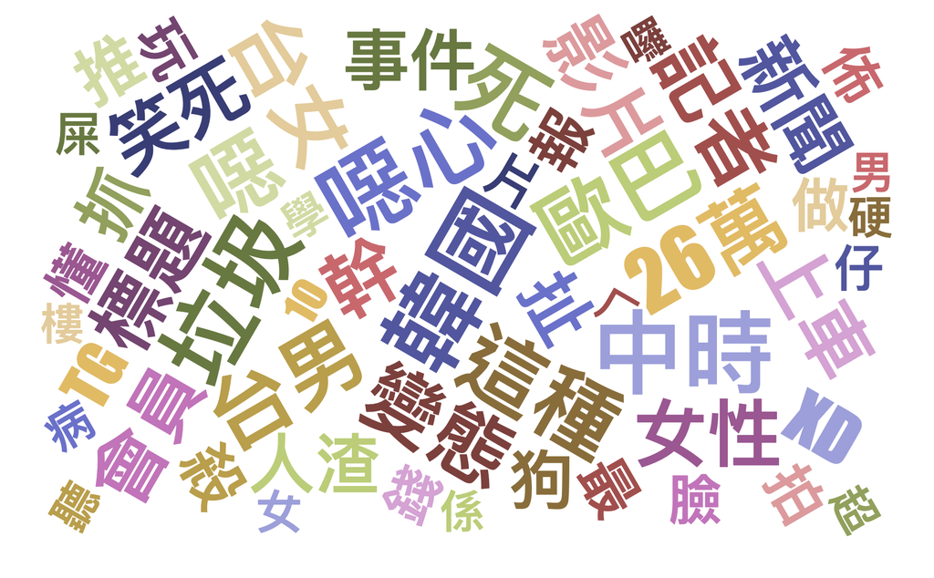

##### 過程紀要：

1.在分析時，因為發現斷詞的狀況並不如預期，許多詞都沒有被切出來，所以自訂了辭典，希望能夠增加段詞的準確度。例如：

- 重要關鍵詞：「性剝削」、「N號房」等
- 常用詞：「批踢踢」、「大紀元」、「民進黨」、「台灣價值」等
- 特殊用詞：「柯黑」、「屎報」等
- 人名：「蔡英文」、「黃暐瀚」、「李家穎」等

2.從詞頻統計中，觀察到有些詞例如「台灣」、「真的」等，出現頻率相當高，在此次的分析中，卻是與主題較不相關，所以先去除。

##### 結果：

從結果看來，對於此事件，ptt的留言中，與一般大眾的態度差不多，認為n號房事件及其中性剝削的手段相當噁心。但部分留言中，仍然出現「台女、最愛的」、「歐巴」等，用較為嘲諷的態度回應。

特別的是，在這一週與n號房的貼文中，出現較多針對中時的批評。追溯原作者李家穎所寫「Telegram老司機爆出N號房事件 蔡英文也有帳號！」一文，內文簡單描述事件，並且在末段加上蔡英文也申請telegram帳號一事，報導有失公正且無新聞性，引起八卦版針對中時的不實報導的討論，不斷攻擊該報以及撰寫報導者。

- 問題一：你是否去除停用詞？是正確的決定嗎？去除的話對你的結果造成什麼影響？
  - 為了讓斷詞結果更能夠凸顯出有意義的詞彙組合，我除了引用[網路整理的停用詞資源](https://github.com/tomlinNTUB/Machine-Learning/blob/master/data/停用詞-繁體中文.txt)外，也在觀察詞頻後，新增了一些需要停用的詞語，例如：「有夠」、「一定」、「到底」、「什麼」等。
  - 在引用之後，斷詞的分析結果，如詞頻或詞對的表現，都能夠避開無意義的詞或是標點符號。
- 問題二：就網路文本而言，是否觀察到一些不被算在停用詞，是否該把它去除？去除的話會有和效果？
  - 除了以上的停用詞處理，我也停用了「台灣」，而我認為停用這個詞可能對結果造成了一些影響，不過，就結果而言，我認為用這個詞，對於我的分析目的較有幫助。
  - 在處理結果中，有些停用詞仍然出現在結果中，需要進一步探究原因。

## Collocation

```python
import pandas as pd

df = pd.read_csv("Nth_room_a_week_ptt.csv")
df.info()
# df.push_timestamp = df.push_timestamp.str.replace(r'(\d+.\d+.\d+.\d+\s)', '')
df.date.min(),df.date.max()
```

```
<class 'pandas.core.frame.DataFrame'>
RangeIndex: 3761 entries, 0 to 3760
Data columns (total 8 columns):
author            3761 non-null object
date              3761 non-null object
post_content      3761 non-null object
title             3761 non-null object
push_tag          3761 non-null object
push_timestamp    3761 non-null object
push_userid       3761 non-null object
push_content      3761 non-null object
dtypes: object(8)
memory usage: 235.1+ KB
```

```
('2020-03-22 22:33:21 Sun', '2020-03-28 21:59:36 Sat')
```

```python
import re

comments = [','.join(df['push_content'].tolist())]
comments = re.sub("[A-Za-z0-9]*[:\/._\-]+[A-Za-z.]*[\/]+[A-Za-z0-9.\/_-]+","",comments[0])
comments =  [",".join(comments.split(","))]
```

```python
import jieba
tokens = [list(jieba.cut(text)) for text in comments]
# for text in comments:
#     print(len(list(jieba.cut(text))))
tokens = tokens[0]


print("Number of raw tokens: %d" % len(tokens))

jieba.load_userdict('ref/user_dict_nth.txt')#user dict

stopwords = open("ref/stopwords_ch_zh.txt").read()#stopword list
stopword_list = [x.strip() for x in stopwords]

tokens = [tok for tok in tokens if tok not in stopword_list]
print(tokens[:100])
print("Number of clean tokens: %d" % len(tokens))
```

```
Building prefix dict from the default dictionary ...
Dumping model to file cache /var/folders/h6/f7rbyffj54s01q99rs8dns5w0000gp/T/jieba.cache
Loading model cost 0.761 seconds.
Prefix dict has been built successfully.
```

```
Number of raw tokens: 32655
['韓男', '日常', '暗網', '永流傳', '台女', '遇到', '白人', '自願', '什麼性', '剝削', '我覺', 'ig', '語錄', '帳號', '邊表態', '超', '好笑', '...', '沒聽過', '一定', '痛心', '教授', '勃起', '自由', '已經', 'fbi', '鎖定', '政治', '正確', '一堆', '掰', '魔', '明明', '不是', '韓國人', '管到', '人家', '內政', '一定', '要表現', '心痛', '才能', '搏女', '同學', '好感', '高等', '白種', '人到', '泰國', …
Number of clean tokens: 17916
```

```python
from collections import Counter


window_size = 4 #先設定一下window size設定小一點開始

word_pair_distance_counts = Counter()
word_pair_counts = Counter()
word_pair_nosw_counts = Counter()

for i in range(len(tokens) - 1):
    for distance in range(1, window_size + 1): #要出來幾對
        if i + distance < len(tokens):
            (w1, w2) = (tokens[i], tokens[i + distance]) #010203
            if w1 not in stopword_list and w2 not in stopword_list:
                word_pair_nosw_counts[(w1, w2)] += 1
                word_pair_distance_counts[(w1, w2, distance)] += 1
                word_pair_counts[(w1, w2)] += 1 #到底有幾個pair

print("\n單純看一下詞對\n")
for (w1, w2), c in word_pair_nosw_counts.most_common(30):
    print("%s\t%s\t%d" % (w1, w2, c))

pair_mean_distances = Counter()
for (w1, w2, distance), c in word_pair_distance_counts.most_common():
    if word_pair_counts[(w1, w2)] > 10:
        pair_mean_distances[(w1, w2)] += distance * c / word_pair_counts[(w1, w2)]

print("\n篩選出現次數小於10的\n")
for (w1, w2), mean_distance in pair_mean_distances.most_common()[:20]:
    print("%s\t%s\t%f\t%d"%(w1, w2, mean_distance, word_pair_counts[(w1, w2)]))

# print(len(word_pair_counts))
print("\n最常見的詞對\n")
for (w1, w2, distance), c in word_pair_distance_counts.most_common(20):
    print("%s\t%s\t%d\t%d" % (w1, w2, distance, c))
```

```
單純看一下詞對

噁	噁	94
真的	噁	62
笑	死	49
李家	穎	34
超	噁	31
韓國	歐巴	30
26	萬人	29
噁	韓國	28
噁	男	26
韓國	噁	24
N	號房	23
噁	爆	23
幹	娘	23
變態	噁	22
韓國	真的	21
死	死	20
...	噁	19
有夠	噁	18
幹	噁	18
垃圾	中時	17
垃圾	媒體	16
中時	記者	16
韓國	社會	15
韓國	韓國	15
噁	歐巴	15
死	中時	15
到底	什麼	14
噁	真的	14
中時	真的	14
中時	中時	14

篩選出現次數小於10的

韓國	韓國	3.600000	15
垃圾	幹	3.000000	11
死	死	2.950000	20
中時	中時	2.928571	14
帳號	中時	2.846154	13
```

[output cut: 23 more lines]

```
噁	噁	1	27
噁	噁	2	27
N	號房	1	23
超	噁	1	23
噁	噁	3	21
幹	娘	1	20
噁	噁	4	19
噁	爆	1	16
有夠	噁	1	14
他媽	噁	1	13
垃圾	媒體	1	12
噁	男	1	11
韓國	韓國	4	11
韓國	社會	1	10
噁	爛	1	10
```

## Term frequency

```python
import pandas as pd

df = pd.read_csv("Nth_room_a_week_ptt.csv")
df.info()
```

```
<class 'pandas.core.frame.DataFrame'>
RangeIndex: 3761 entries, 0 to 3760
Data columns (total 8 columns):
author            3761 non-null object
date              3761 non-null object
post_content      3761 non-null object
title             3761 non-null object
push_tag          3761 non-null object
push_timestamp    3761 non-null object
push_userid       3761 non-null object
push_content      3761 non-null object
dtypes: object(8)
memory usage: 235.1+ KB
```

```python
# df.push_timestamp = df.push_timestamp.str.replace(r'(\d+.\d+.\d+.\d+\s)', '')
df.date.min(),df.date.max()
```

```
('2020-03-22 22:33:21 Sun', '2020-03-28 21:59:36 Sat')
```

```python
comments = [','.join(df['push_content'].tolist())]
type(comments)
```

```
list
```

```python
import re

comments = re.sub("[A-Za-z0-9]*[:\/._\-]+[A-Za-z.]*[\/]+[A-Za-z0-9.\/_-]+","",comments[0])
type(comments.split(","))
comments = [",".join(comments.split(","))]
type(comments)
```

```
list
```

```python
import jieba
# from nltk.tokenize import word_tokenize
tokens = [list(jieba.cut(text)) for text in comments]


# for text in comments:
#     print(len(list(jieba.cut(text))))

tokens = tokens[0]
print("Number of tokens: %d" % len(tokens))
type(tokens)
```

```
Number of tokens: 32188
```

```
list
```

```python
from collections import Counter
word_counts = Counter(tokens)
for w, c in word_counts.most_common(50):
    print("%s\t%d" % (w, c))
```

```
,	3778
的	919
，	683
是	447
有	438
了	428
噁	367
？	334
也	298
都	238
就	236
你	232
不	227
韓國	221
嗎	213
真的	192
嘔	187
啊	182
好	182
在	176
人	169
死	169
吧	166
垃圾	160
我	157
被	156
看	149
中時	149
心	146
很	137
。	130
說	127
?	122
沒	119
！	117
要	115
台	114
這種	109
不是	107
就是	107
跟	103
台灣	98
會	97
26	96
來	95
男	94
可以	93
啦	90
什麼	88
自己	87
```

```python
jieba.load_userdict('ref/user_dict_nth.txt')#user dict

stopwords = open("ref/stopwords_ch_zh.txt").read()#stopword list
stopword_list = [x.strip() for x in stopwords]
```

```python
#要做文字雲的template
import unicodedata
from collections import Counter
word_counts = Counter()
for word in tokens:
    if word in stopwords:
        continue
    if len(word) > 1 or not unicodedata.category(word).startswith('P'):
            word_counts[word] += 1
print(word_counts.most_common(30))
repeated_tokens = []
for w, c in word_counts.most_common():
    for i in range(c):
        repeated_tokens.append(w)
print(" ".join(repeated_tokens))
```

```
[('韓國', 207), ('噁心', 184), ('中時', 183), ('垃圾', 160), ('死', 126), ('歐巴', 120), ('噁', 112), ('這種', 108), ('台男', 99), ('26萬', 92), ('台女', 90), ('變態', 82), ('記者', 80), ('帳號', 75), ('幹', 70), ('影片', 61), ('標題', 61), ('女性', 60), ('會員', 57), ('上車', 54), ('笑死', 54), ('新聞', 46), ('扯', 43), ('XD', 41), ('犯罪',…
韓國 韓國 韓國 韓國 韓國 韓國 韓國 韓國 韓國 韓國 韓國 韓國 韓國 韓國 韓國 韓國 韓國 韓國 韓國 韓國 韓國 韓國 韓國 韓國 韓國 韓國 韓國 韓國 韓國 韓國 韓國 韓國 韓國 韓國 韓國 韓國 韓國 韓國 韓國 韓國 韓國 韓國 韓國 韓國 韓國 韓國 韓國 韓國 韓國 韓國 韓國 韓國 韓國 韓國 韓國 韓國 韓國 韓國 韓國 韓國 韓國 韓國 韓國 韓國 韓國 韓國 韓國 韓國 韓國 韓國 韓國 韓國 韓國 韓國 韓國 韓國 韓國 韓國 韓國 韓國 韓國 韓國 韓國 韓國 韓國 韓國 韓國 韓國 韓國 韓國 韓國 韓國 韓國 韓國 韓國 韓國 韓國 韓國 韓國 韓國 …
```